# Reading Notes - Winter Ch.5

Hanna Mahler

15 5 2020

# Reading Notes - Winter Chapter 5 “Correlation, Linear, and Nonlinear Transformations”

## 5.1 Centering

- “A linear transformation involves addition, subtraction, multiplication, or division with a constant value.” This does not change the relationship between the original numbers, it mererly affects the unit of the axis!
- linear transformations are helpful for more interpretable metrics (e.g. change from milliseconds to seconds)
- “centring” is a type of linear transformation, often applied to continuous predictor variables: “To center a predictor variable, subtract the mean of that predictor variable from each data point.” -> this changes the value of the intercept, it is now the predicted y-value for the mean of x. (the slope is not affected by centering)
- centering often helps to make the intercept meaningful, especially with predictors that have no value for zero (such as height or weight)

## 5.2 Standardizing

- “standardizing”/“Z-scoring” is another type of linear transformation
- “For standardizing, the centred variable is divided by the standard deviation of the sample”
- “standardization involves re-expressing the data in terms of how many standard deviations they are away from the mean. The resultant numbers are in ‘standard units’, often represented by letter z.”

## 5.3 Correlation

- one can also standardize both the response and the predictor variable and fit a regression model to them: “the corresponding regression model will estimate how much change in y standard units results from a corresponding change in x standard units” -> the slope of this regression model is called the “correlation coefficient” or “Pearson’s r”
- “Person’s r is a standardized metric of how much two variables are correlated with each other”, it ranges between -1 and 1.
- If y increases as x increases, the correlation coefficient is positive. If y decreases as x increases, the correlation coefficient is negative. The farther away from zero, the stronger the correlation.

## 5.4 Using Logarithms to Describe Magnitudes

```r
RTs = c(600, 650, 700, 1000, 4000)
RTs
```

```
## [1]  600  650  700 1000 4000
```

```r
logRTs = log(RTs)
logRTs
```

```
## [1] 6.396930 6.476972 6.551080 6.907755 8.294050
```

## 5.5 Example: Response Durations and Word Frequency

```r
library(tidyverse)
library(broom)
library(languageR)

vector1 = c("thing","life","door","angel","beer","disgrace","kitten","bloke","mocha","gnome","nihilism","puffball")
vector2 = c(55522,40629,14895,3992,3850,409,241,238,66,32,4,4)
vector3 = c(622,520,507,637,587,705,611,794,725,810,764,878)
ELP = tibble("Word" = vector1, "Freq" = vector2, "RT" = vector3)
ELP
```

```
## # A tibble: 12 x 3
##    Word      Freq    RT
##    <chr>    <dbl> <dbl>
##  1 thing    55522   622
##  2 life     40629   520
##  3 door     14895   507
##  4 angel     3992   637
##  5 beer      3850   587
##  6 disgrace   409   705
##  7 kitten     241   611
##  8 bloke      238   794
##  9 mocha       66   725
## 10 gnome       32   810
## 11 nihilism     4   764
## 12 puffball     4   878
```

```r
ELP = mutate(ELP, Log10Freq = log10(Freq), LogRT = log(RT))
ELP
```

```
## # A tibble: 12 x 5
##    Word      Freq    RT Log10Freq LogRT
##    <chr>    <dbl> <dbl>     <dbl> <dbl>
##  1 thing    55522   622     4.74   6.43
##  2 life     40629   520     4.61   6.25
##  3 door     14895   507     4.17   6.23
##  4 angel     3992   637     3.60   6.46
##  5 beer      3850   587     3.59   6.38
##  6 disgrace   409   705     2.61   6.56
##  7 kitten     241   611     2.38   6.42
##  8 bloke      238   794     2.38   6.68
##  9 mocha       66   725     1.82   6.59
## 10 gnome       32   810     1.51   6.70
## 11 nihilism     4   764     0.602  6.64
## 12 puffball     4   878     0.602  6.78
```

- Visualising the effect of logarithmic transformation:

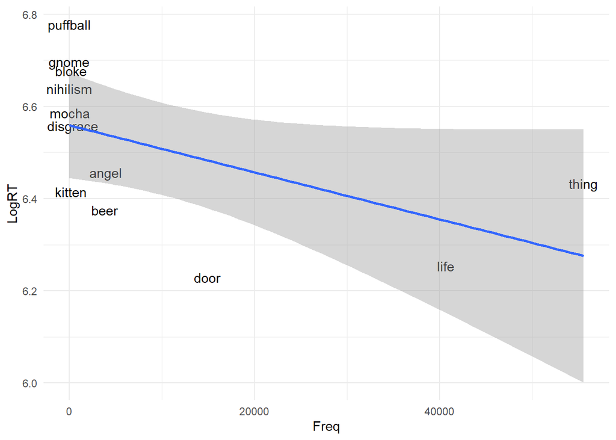

```r
ELP %>% ggplot(aes(x = Freq, y = LogRT, label = Word)) + geom_text() + geom_smooth(method = "lm") + theme_minimal()
```

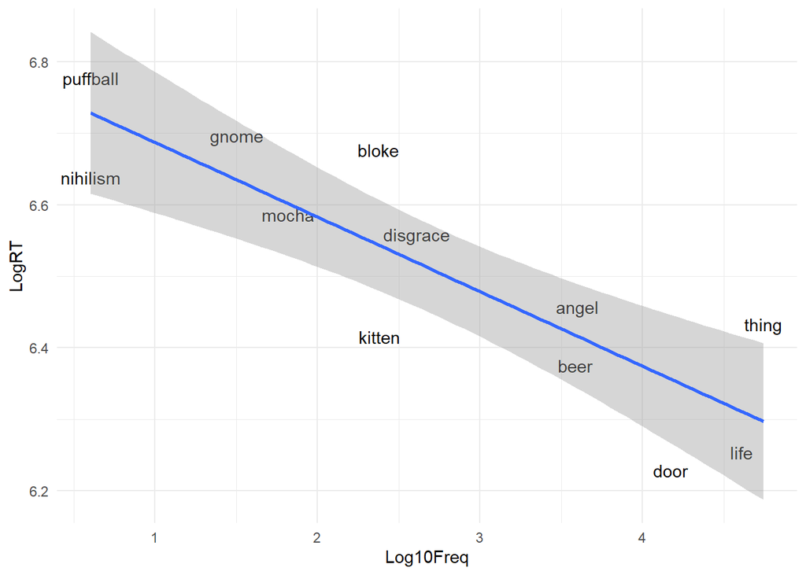

```r
ELP %>% ggplot(aes(x = Log10Freq, y = LogRT, label = Word)) + geom_text() + geom_smooth(method = "lm") + theme_minimal()
```

- fitting a model with transformed values:

```r
ELP_mdl = lm(LogRT ~ Log10Freq, data = ELP)
tidy(ELP_mdl)
```

```
## # A tibble: 2 x 5
##   term        estimate std.error statistic  p.value
##   <chr>          <dbl>     <dbl>     <dbl>    <dbl>
## 1 (Intercept)    6.79     0.0612    111.   8.67e-17
## 2 Log10Freq     -0.104    0.0201     -5.19 4.06e- 4
```

- the resulting coefficient for frequency is negative: as frequency of a word increases, the reaction times are smaller
- to obtain the predicted values, we first need to extract the intercept and slope, then enter the log-transformed x-value before re-converting the output to the original metric with the exp() function

```r
# extracting the intercept of the model:
b0 = tidy(ELP_mdl)$estimate[1]
# extracting the slope of the model:
b1 = tidy(ELP_mdl)$estimate[2]

logRT_10freq =  b0 + b1*1
logRT_1000freq = b0 + b1*3
exp(logRT_10freq)
```

```
## [1] 802.0706
```

```r
exp(logRT_1000freq)
```

```
## [1] 651.0792
```

## 5.6 Centering and Standardization in R

- create a centred and a standardized column in the previous data frame

```r
ELP = mutate(ELP, Log10Freq_c = Log10Freq - mean(Log10Freq), Log10Freq_z = Log10Freq_c / sd(Log10Freq_c))
select(ELP, Freq, Log10Freq, Log10Freq_c, Log10Freq_z)
```

```
## # A tibble: 12 x 4
##     Freq Log10Freq Log10Freq_c Log10Freq_z
##    <dbl>     <dbl>       <dbl>       <dbl>
##  1 55522     4.74        2.03       1.41
##  2 40629     4.61        1.89       1.31
##  3 14895     4.17        1.46       1.01
##  4  3992     3.60        0.884      0.614
##  5  3850     3.59        0.868      0.603
##  6   409     2.61       -0.106     -0.0736
##  7   241     2.38       -0.336     -0.233
##  8   238     2.38       -0.341     -0.237
##  9    66     1.82       -0.898     -0.624
## 10    32     1.51       -1.21      -0.842
## 11     4     0.602      -2.12      -1.47
## 12     4     0.602      -2.12      -1.47
```

```r
# alternatively, use the scale() function for standardizing and scale(scale = FALSE) for centering:
ELP = mutate(ELP, Log10Freq_c = scale(Log10Freq, scale = FALSE), Log10Freq_z = scale(Log10Freq))
```

- fit a model based on the standardized/centred predictors

```r
ELP_mdl_c = lm(LogRT ~ Log10Freq_c, data = ELP)
ELP_mdl_z = lm(LogRT ~ Log10Freq_z, data = ELP)
tidy(ELP_mdl) %>% select(term, estimate)
```

```
## # A tibble: 2 x 2
##   term        estimate
##   <chr>          <dbl>
## 1 (Intercept)    6.79
## 2 Log10Freq     -0.104
```

```r
tidy(ELP_mdl_c) %>% select(term, estimate)
```

```
## # A tibble: 2 x 2
##   term        estimate
##   <chr>          <dbl>
## 1 (Intercept)    6.51
## 2 Log10Freq_c   -0.104
```

```r
# the intercept has changed
tidy(ELP_mdl_z) %>% select(term, estimate)
```

```
## # A tibble: 2 x 2
##   term        estimate
##   <chr>          <dbl>
## 1 (Intercept)    6.51
## 2 Log10Freq_z   -0.150
```

```r
# the slope has changed

# each model represents the same underlying correlation, check:
glance(ELP_mdl)
```

```
## # A tibble: 1 x 12
##   r.squared adj.r.squared  sigma statistic p.value    df logLik   AIC   BIC
##       <dbl>         <dbl>  <dbl>     <dbl>   <dbl> <dbl>  <dbl> <dbl> <dbl>
## 1     0.729         0.702 0.0959      27.0 4.06e-4     1   12.2 -18.4 -16.9
## # ... with 3 more variables: deviance <dbl>, df.residual <int>, nobs <int>
```

```r
glance(ELP_mdl_c)
```

```
## # A tibble: 1 x 12
##   r.squared adj.r.squared  sigma statistic p.value    df logLik   AIC   BIC
##       <dbl>         <dbl>  <dbl>     <dbl>   <dbl> <dbl>  <dbl> <dbl> <dbl>
## 1     0.729         0.702 0.0959      27.0 4.06e-4     1   12.2 -18.4 -16.9
## # ... with 3 more variables: deviance <dbl>, df.residual <int>, nobs <int>
```

```r
glance(ELP_mdl_z)
```

```
## # A tibble: 1 x 12
##   r.squared adj.r.squared  sigma statistic p.value    df logLik   AIC   BIC
##       <dbl>         <dbl>  <dbl>     <dbl>   <dbl> <dbl>  <dbl> <dbl> <dbl>
## 1     0.729         0.702 0.0959      27.0 4.06e-4     1   12.2 -18.4 -16.9
## # ... with 3 more variables: deviance <dbl>, df.residual <int>, nobs <int>
```

```r
# calculate the correlation coefficient Pearson's r
with(ELP, cor(Log10Freq, LogRT))
```

```
## [1] -0.8540557
```

```r
# this is equal to the coefficient produced by a regression model using the z-scored predictor and response variables
ELP_cor = lm(scale(LogRT) ~ -1 + Log10Freq_z, ELP)
tidy(ELP_cor) %>% select(estimate)
```

```
## # A tibble: 1 x 1
##   estimate
##      <dbl>
## 1   -0.854
```

## 5.7 Terminological Note on the Term ‘Normalizing’

- the term is used to refer to standardization or to nonlinear transformations

## 5.9 Exercises

- r = 1, r = 0.9, r = - 0.7
- r = 0.3, r = 0, r = - 0.5